# GLMNET MINT

Felix Leborgne, Carolina Rivero y Santiago Escobar

2023-11-10

```r
library(glmnet)
library(dplyr)
library(caret)
library(tidyverse)
library(pROC)
```

## 1. Dataset pre-processing

We will proceed to clean the dataset (remove unneesary columns) and process it. Numerical columns will be standardized and binomial categorical columns will be encoded with a 1 and 0. The function $makeX()$ does One Hot Encoding and imputes the missing values.

```r
# Import dataset
data <- read.csv("data/telco_churn_data.csv")

set.seed(1)

# Reove unnecesary columns
data <- subset(data, select = -c(Customer.Satisfaction, City, Customer.ID,
                                 Churn.Category, Churn.Reason, Population, Latitude,
                                 Longitude, Under.30, Senior.Citizen))

# Separate numerical and categorical features
numerical_columns <- data %>% select_if(is.numeric)
categorical_columns <- data[ ,sapply(data, is.character)]

# Encoding binary categorical variables
for (col in names(data)) {
  if (nrow(unique(data[col])) == 2){
    data[,col] <- as.numeric(factor(data[,col]))-1    # The -1 is to transform (2,1) to (1,0)
  }
}

# Scale numerical features
numerical_columns <- subset(numerical_columns, select = -Churn.Value)
data[names(numerical_columns)] <- scale(data[names(numerical_columns)])

# Does one hot encoding and imputes missing values
data <- makeX(data)

# Train and test split
row_split <- sample(1:nrow(data), 0.75 * nrow(data))
X_train <- data[row_split,] %>% subset(select = -Churn.Value)
X_test <- data[-row_split,] %>% subset(select = -Churn.Value)
y_train <- data[row_split, "Churn.Value"]
y_test <- data[-row_split, "Churn.Value"]
```

## 2. Train Models

First, we will train Lasso and Ridge regularizations and compare the models. Afterwards, we will train an Elastic Net with 10 alphas to compare all the models in between Ridge and Lasso. Finally, we will evaluate the model with the highest accuracy score and compare it to the Logistic Regression we already made in Python.

### 2.1. Lasso Regularization

```r
set.seed(1)

# Fit the model
lasso.fit <- cv.glmnet(X_train, y_train, alpha=1, family="binomial")

# Predict values
lasso.predicted <- predict(lasso.fit, s=lasso.fit$lambda.1se, newx=X_test)
lasso.classes <- ifelse(lasso.predicted > 0.5, 1, 0) %>% as.numeric()

# Accuracy of model
print(paste("Model accuracy =", mean(y_test == lasso.classes)))
```

```
## [1] "Model accuracy = 0.907438955139126"
```

```r
# Show the largest coefficients
coefsl <- coef(lasso.fit, lasso.fit$lambda.1se)
coefsl[,1][order(-abs(coefsl[,1]))][2:9]
```

```
##      ContractMonth-to-Month         Number.of.Referrals
##                   1.3858233                  -1.3235292
##                  Dependents Total.Customer.Svc.Requests
##                  -1.2382647                   1.1865242
##              Unlimited.Data              Monthly.Charge
##                  -1.1379993                   1.0502082
##                     Married          Internet.TypeCable
##                   0.8637271                   0.8548754
```

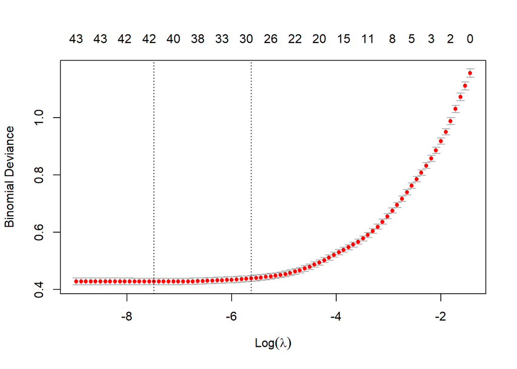

```r
# Plot lasso
plot(lasso.fit)
```

### 2.2. Ridge Regularization

```r
set.seed(1)

# Fit the model
ridge.fit <- cv.glmnet(X_train, y_train, alpha=0, family="binomial")

# Predict values
ridge.predicted <- predict(ridge.fit, s=ridge.fit$lambda.1se, newx=X_test)
ridge.classes <- ifelse(ridge.predicted > 0.5, 1, 0)

# Accuracy of model
print(paste("Model accuracy =", mean(y_test == ridge.classes)))
```

```
## [1] "Model accuracy = 0.898921067575241"
```

```r
# Show the largest coefficients
coefsl <- coef(ridge.fit, ridge.fit$lambda.1se)
coefsl[,1][order(-abs(coefsl[,1]))][2:9]
```

```
##      ContractMonth-to-Month Total.Customer.Svc.Requests
##                   0.8492958                   0.8440275
##            ContractTwo Year              Unlimited.Data
##                  -0.8207407                  -0.7836637
##          Internet.TypeCable                  Dependents
##                   0.7410959                  -0.6750311
##         Number.of.Referrals  Payment.MethodMailed Check
##                  -0.5836746                   0.5002975
```

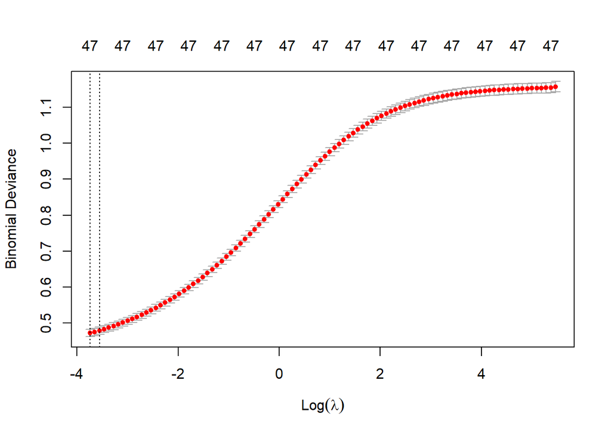

```r
# Plot lasso
plot(ridge.fit)
```

### 2.3. Elastic Net

```r
# Elastic Net (changing alpha)
set.seed(1)

# Create a list of fits for alphas 0 to 1 increasing in 0.1
list_fits <- list()
for (i in 0:10) {
  fit_name <- paste0("alpha", i/10)
  list_fits[[fit_name]] <-
    cv.glmnet(X_train, y_train, alpha=i/10, family="binomial")
}

# Create a data frame with the results of the predictions and their accuracy
results <- data.frame()
for (i in 0:10) {
  fit_name <- paste0("alpha", i/10)
  predicted <- predict(list_fits[[fit_name]], s=list_fits[[fit_name]]$lambda.1se, newx=X_test)
  predicted.classes <- ifelse(predicted > 0.5, 1, 0)
  accuracy <- mean(y_test == predicted.classes)
  temp <- data.frame(alpha=i/10, accuracy=accuracy, fit_name=fit_name)
  results <- rbind(results, temp)
}

print(results)
```

```
##    alpha  accuracy fit_name
## 1    0.0 0.8989211   alpha0
## 2    0.1 0.9057354 alpha0.1
## 3    0.2 0.9063032 alpha0.2
## 4    0.3 0.9068711 alpha0.3
## 5    0.4 0.9063032 alpha0.4
## 6    0.5 0.9063032 alpha0.5
## 7    0.6 0.9051675 alpha0.6
## 8    0.7 0.9063032 alpha0.7
## 9    0.8 0.9063032 alpha0.8
## 10   0.9 0.9068711 alpha0.9
## 11   1.0 0.9063032   alpha1
```

As we can see, all the models from $alpha=0.2$ onwards have basically the same accuracy equal to $0.906$. For this reason, we will use the simpler $alpha=1$ Lasso regression, which will help us determine which features are the most significant in predicting churn.

## 3. Model Evaluation

```r
# Accuracy of model
print(paste("Model accuracy =", mean(y_test == lasso.classes)))
```

```
## [1] "Model accuracy = 0.907438955139126"
```

```r
# Show the largest coefficients
coefsl <- coef(lasso.fit, lasso.fit$lambda.1se)
print(coefsl[,1][order(-abs(coefsl[,1]))][2:9])
```

```
##      ContractMonth-to-Month         Number.of.Referrals
##                   1.3858233                  -1.3235292
##                  Dependents Total.Customer.Svc.Requests
##                  -1.2382647                   1.1865242
##              Unlimited.Data              Monthly.Charge
##                  -1.1379993                   1.0502082
##                     Married          Internet.TypeCable
##                   0.8637271                   0.8548754
```

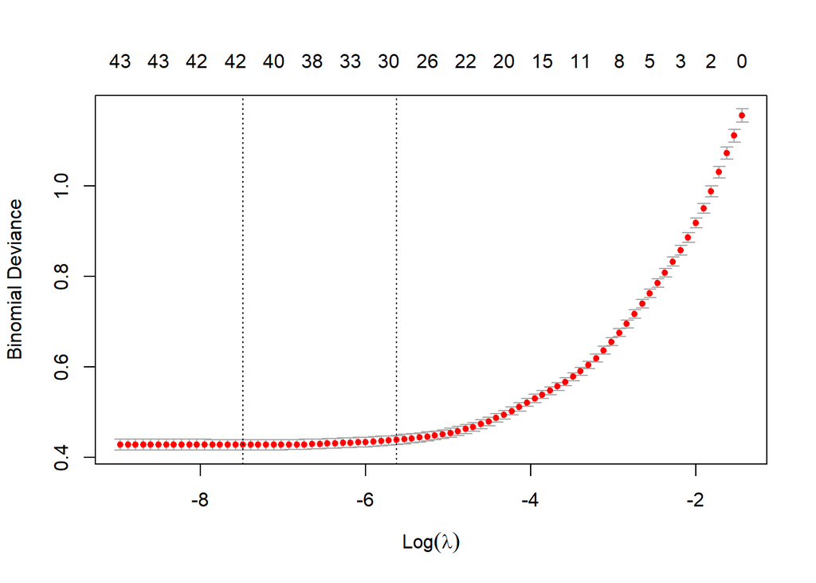

```r
# Plot lasso
plot(lasso.fit)
```

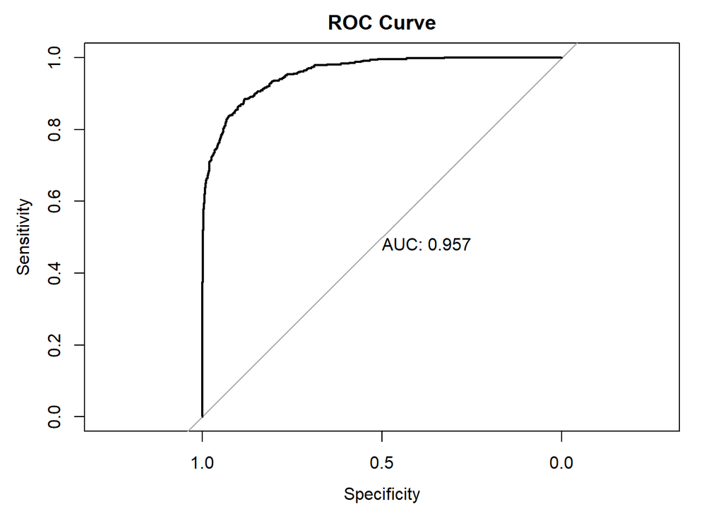

```r
# Plot a ROC curve
roc_curve <- roc(y_test, lasso.predicted)
plot(roc_curve, main = "ROC Curve", print.auc = TRUE)
```

```r
# Create a confusion matrix
confusion_matrix <- confusionMatrix(factor(as.vector(lasso.classes)), factor(y_test))

# Print the confusion matrix
print(confusion_matrix)
```

```
## Confusion Matrix and Statistics
##
##           Reference
## Prediction    0    1
##          0 1258  128
##          1   35  340
##
##                Accuracy : 0.9074
##                  95% CI : (0.8929, 0.9206)
##     No Information Rate : 0.7342
##     P-Value [Acc > NIR] : < 2.2e-16
##
##                   Kappa : 0.7468
##
##  Mcnemar's Test P-Value : 5.762e-13
##
##             Sensitivity : 0.9729
##             Specificity : 0.7265
##          Pos Pred Value : 0.9076
##          Neg Pred Value : 0.9067
##              Prevalence : 0.7342
##          Detection Rate : 0.7144
##    Detection Prevalence : 0.7871
##       Balanced Accuracy : 0.8497
##
##        'Positive' Class : 0
##
```

```r
# F1, Precision and Recall metrics
classification_report <- confusion_matrix$byClass
print(classification_report[5:7])
```

```
## Precision    Recall        F1
## 0.9076479 0.9729312 0.9391564
```

The AUC of the ROC graph in this model is $0.957$, which is better than the AUC of normal Logistic regression of $0.93$.

In the lasso curve we can see that the minimum cross validation error is on 42 features, but taking 1 standard deviation, the amount of non-zero features drops to 30. The 8 most important featurs are printed above.